# SMITH-STUDY: Self-Efficacy Scale (EIPSES) Pre-Post Analysis

2026-08-05

# 1. Setup & Data Ingestion

## 1.1 Libraries

```r
library(dplyr)       # Data manipulation
library(stringr)     # String manipulation
library(tidyr)       # Data pivoting
library(readr)       # Reading data
library(kableExtra)  # HTML Table formatting
library(ggplot2)     # Visualizations
library(ggpubr)      # Publication-ready plots
library(rstatix)     # T-tests and effect sizes
library(broom)       # Tidy statistical outputs
library(forcats)     # Factor manipulation
library(effectsize)  # effect size & omega squared
```

## 1.2 Load Data

```r
# Read in raw dataset
SEFF.raw <- read_csv("../_data/Self-efficacy data.csv", col_names = TRUE)

# Extract and Clean Column Names
sEFF.named <- SEFF.raw %>%
  rename("StudyID" = "Number assigned by study staff",
         "PRE_SE_Score" = "Pre SE Score",
         "POST_SE_Score" = "Post SE Score") %>%
  rename_with(~paste0("PRE_Q", (as.numeric(str_extract(., "\\d+$"))-1)), .cols = 2:17) %>%
  rename_with(~paste0("POST_Q", (as.numeric(str_extract(., "\\d+$"))-18)), .cols = 19:34) %>%
  mutate(across(contains("_Q"), tolower)) #ALL QUESTION TEXT tolower, because original sheet has 'Agree' and 'agree'

#table(is.na(sEFF.named$StudyID)) # Check for missing StudyIDs two empty rows, for whatever reason
sEFF.filtered <- sEFF.named %>%
  filter(!is.na(StudyID)) %>% # Remove rows with missing StudyIDs
  select(-PRE_SE_Score, -POST_SE_Score) # drop unused cols from data
```

# 2. Scoring & Data Transformation

## 2.1 Scoring Guidelines (Guimond et al., 2008):

```
- Mean/Total scores are computed by aggregating all items of the specific scale.
- Reverse Scored Items: 3, 5, 6, 8, 10, 12, 13, 15, 16.
- Parent Outcome Expectations: 3, 4, 5, 6, 7, 8, 10, 12, 15, 16.
- Parent Competence: 1, 2, 9, 14.
```

```r
sEFF.mutated <- sEFF.filtered %>%
  select(StudyID, contains("PRE_"), contains("POST_")) %>%
  mutate(StudyID = paste0("seffID_", as.character(StudyID))) %>%

  # 1. Convert text to numeric Likert (1-7)
  mutate(across(contains("_Q"), ~case_match(.,
    "strongly disagree" ~ 1,
    "disagree" ~ 2,
    "somewhat disagree" ~ 3,
    "neutral" ~ 4,
    "somewhat agree" ~ 5,
    "agree" ~ 6,
    "strongly agree" ~ 7,
    .default = NA_real_
  ))) %>%

  # 2. Reverse Code specific items
  mutate(across(ends_with(c("Q3", "Q5", "Q6", "Q8", "Q10", "Q12", "Q13", "Q15", "Q16")),
                ~ 8 - .)) %>% # Quick math trick for 1-7 reverse coding (8 - 1 = 7, 8 - 7 = 1)

  # 3. Mean replace NAs
  mutate(across(contains("_Q"), ~ifelse(is.na(.), mean(., na.rm = TRUE), .))) %>%

  # 4. Calculate Composite Totals
  mutate(
    # PRE Composites
    PRE_Parent_Outcome_Expectations.Sum = rowSums(select(., ends_with(c("PRE_Q3", "PRE_Q4", "PRE_Q5", "PRE_Q6", "PRE_Q7", "PRE_Q8", "PRE_Q10", "PRE_Q12", "PRE_Q15", "PRE_Q16"))), na.rm = TRUE),
    PRE_Parent_Competence.Sum = rowSums(select(., ends_with(c("PRE_Q1", "PRE_Q2", "PRE_Q9", "PRE_Q14"))), na.rm = TRUE),
    PRE_Overall_SEFF.Sum = rowSums(select(., contains("PRE_Q")), na.rm = TRUE),

    # POST Composites
    POST_Parent_Outcome_Expectations.Sum = rowSums(select(., ends_with(c("POST_Q3", "POST_Q4", "POST_Q5", "POST_Q6", "POST_Q7", "POST_Q8", "POST_Q10", "POST_Q12", "POST_Q15", "POST_Q16"))), na.rm = TRUE),
    POST_Parent_Competence.Sum = rowSums(select(., ends_with(c("POST_Q1", "POST_Q2", "POST_Q9", "POST_Q14"))), na.rm = TRUE),
    POST_Overall_SEFF.Sum = rowSums(select(., contains("POST_Q")), na.rm = TRUE)
  ) %>%
  # 5. Calculate Composite MEANS
  mutate(
    # PRE Composites
    PRE_Parent_Outcome_Expectations.Mean = rowMeans(select(., ends_with(c("PRE_Q3", "PRE_Q4", "PRE_Q5", "PRE_Q6", "PRE_Q7", "PRE_Q8", "PRE_Q10", "PRE_Q12", "PRE_Q15", "PRE_Q16"))), na.rm = TRUE),
    PRE_Parent_Competence.Mean = rowMeans(select(., ends_with(c("PRE_Q1", "PRE_Q2", "PRE_Q9", "PRE_Q14"))), na.rm = TRUE),
    PRE_Overall_SEFF.Mean = rowMeans(select(., contains("PRE_Q")), na.rm = TRUE),

    # POST Composites
    POST_Parent_Outcome_Expectations.Mean = rowMeans(select(., ends_with(c("POST_Q3", "POST_Q4", "POST_Q5", "POST_Q6", "POST_Q7", "POST_Q8", "POST_Q10", "POST_Q12", "POST_Q15", "POST_Q16"))), na.rm = TRUE),
    POST_Parent_Competence.Mean = rowMeans(select(., ends_with(c("POST_Q1", "POST_Q2", "POST_Q9", "POST_Q14"))), na.rm = TRUE),
    POST_Overall_SEFF.Mean = rowMeans(select(., contains("POST_Q")), na.rm = TRUE)
  ) %>%
  mutate(Filter_Diff = POST_Overall_SEFF.Mean - PRE_Overall_SEFF.Mean)

if(is.na(sEFF.mutated) %>% sum() > 0){
  # Check for any remaining NAs in the final scored dataset
  print("ERROR - NA OR MISSING DATA")
}
```

## 2.2 Participant Filtering

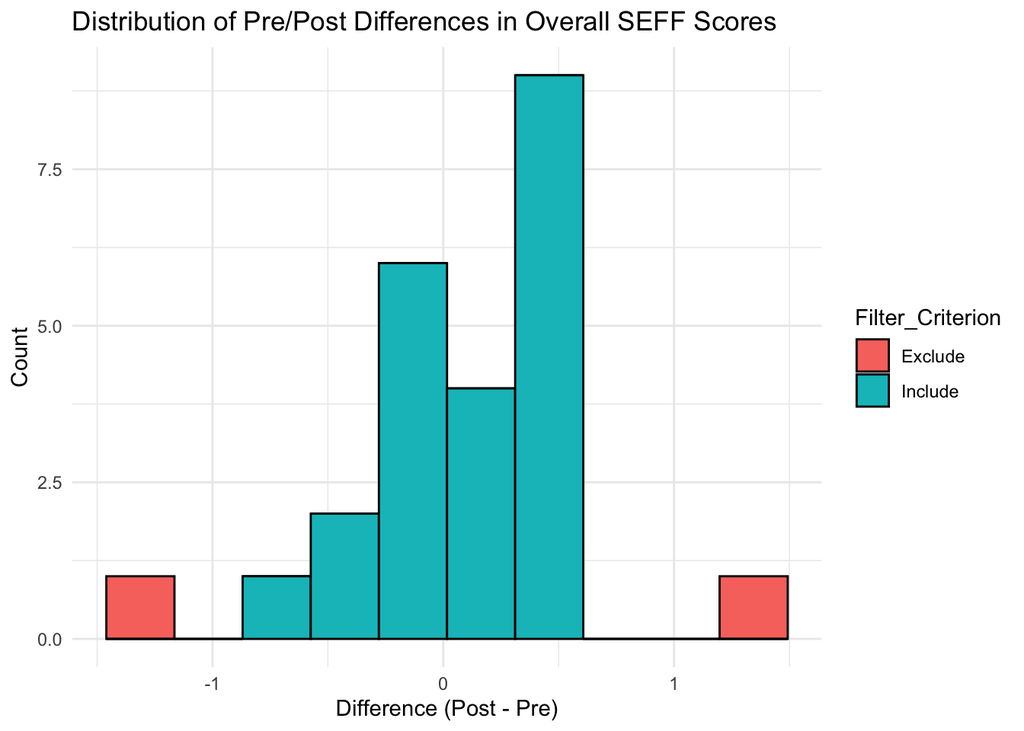

```r
f.mn <- mean(sEFF.mutated$Filter_Diff)
f.sd <- sd(sEFF.mutated$Filter_Diff)

sEFF.clean <- sEFF.mutated %>%
  mutate(
    Filter_Criterion = ifelse(Filter_Diff > (f.mn + 2*f.sd) | Filter_Diff < (f.mn - 2*f.sd), "Exclude", "Include")
  )

sEFF.clean %>% ggplot(aes(x=Filter_Diff, fill = Filter_Criterion)) + geom_histogram(bins=10, color="black") +
  labs(title="Distribution of Pre/Post Differences in Overall SEFF Scores", x="Difference (Post - Pre)", y="Count") +
  theme_minimal()
```

## 2.3 Final Data Filtering - Filter to only the “Include” participants - Save Data

```r
sEFF.clean <- sEFF.clean %>% filter(Filter_Criterion == "Include")
save(sEFF.clean, file = "../_data/sEFF_cleaned.RData")
```

```r
load(file = "../_data/sEFF_cleaned.RData", verbose=TRUE)
```

```
## Loading objects:
##   sEFF.clean
```

```r
# Preview final scored data
sEFF.clean %>%
  select(StudyID, ends_with(c(".Sum",".Mean"))) %>%
  #head(5) %>%
  kable(caption="Sample of Calculated Composite Scores") %>%
  kable_styling(bootstrap_options = c("striped", "hover"), full_width = F)
```

Sample of Calculated Composite Scores

| StudyID | PRE_Parent_Outcome_Expectations.Sum | PRE_Parent_Competence.Sum | PRE_Overall_SEFF.Sum | POST_Parent_Outcome_Expectations.Sum | POST_Parent_Competence.Sum | POST_Overall_SEFF.Sum | PRE_Parent_Outcome_Expectations.Mean | PRE_Parent_Competence.Mean | PRE_Overall_SEFF.Mean | POST_Parent_Outcome_Expectations.Mean | POST_Parent_Competence.Mean | POST_Overall_SEFF.Mean |
| --- | --- | --- | --- | --- | --- | --- | --- | --- | --- | --- | --- | --- |
| seffID_1 | 61.0 | 20 | 94.0 | 63 | 24 | 99 | 6.10 | 5.00 | 5.88 | 6.3 | 6.00 | 6.19 |
| seffID_10 | 43.0 | 19 | 67.0 | 38 | 17 | 61 | 4.30 | 4.75 | 4.19 | 3.8 | 4.25 | 3.81 |
| seffID_14 | 48.0 | 26 | 87.0 | 55 | 20 | 85 | 4.80 | 6.50 | 5.44 | 5.5 | 5.00 | 5.31 |
| seffID_17 | 51.0 | 22 | 85.0 | 55 | 23 | 90 | 5.10 | 5.50 | 5.31 | 5.5 | 5.75 | 5.62 |
| seffID_26 | 52.0 | 25 | 90.0 | 60 | 24 | 98 | 5.20 | 6.25 | 5.62 | 6.0 | 6.00 | 6.12 |
| seffID_39 | 56.0 | 23 | 92.0 | 56 | 25 | 92 | 5.60 | 5.75 | 5.75 | 5.6 | 6.25 | 5.75 |
| seffID_42 | 56.0 | 26 | 89.0 | 58 | 27 | 97 | 5.60 | 6.50 | 5.56 | 5.8 | 6.75 | 6.06 |
| seffID_6 | 56.0 | 24 | 92.0 | 58 | 24 | 90 | 5.60 | 6.00 | 5.75 | 5.8 | 6.00 | 5.62 |
| seffID_50 | 50.0 | 21 | 83.0 | 56 | 23 | 92 | 5.00 | 5.25 | 5.19 | 5.6 | 5.75 | 5.75 |
| seffID_28 | 52.0 | 24 | 88.0 | 50 | 24 | 86 | 5.20 | 6.00 | 5.50 | 5.0 | 6.00 | 5.38 |
| seffID_22 | 50.0 | 25 | 88.0 | 46 | 26 | 84 | 5.00 | 6.25 | 5.50 | 4.6 | 6.50 | 5.25 |
| seffID_53 | 58.0 | 26 | 98.0 | 55 | 21 | 86 | 5.80 | 6.50 | 6.12 | 5.5 | 5.25 | 5.38 |
| seffID_16 | 51.0 | 23 | 87.0 | 49 | 22 | 83 | 5.10 | 5.75 | 5.44 | 4.9 | 5.50 | 5.19 |
| seffID_40 | 53.0 | 17 | 82.0 | 54 | 18 | 84 | 5.30 | 4.25 | 5.12 | 5.4 | 4.50 | 5.25 |
| seffID_58 | 47.0 | 22 | 81.0 | 52 | 18 | 83 | 4.70 | 5.50 | 5.06 | 5.2 | 4.50 | 5.19 |
| seffID_32 | 62.0 | 27 | 103.0 | 70 | 28 | 112 | 6.20 | 6.75 | 6.44 | 7.0 | 7.00 | 7.00 |
| seffID_45 | 49.0 | 20 | 80.0 | 53 | 19 | 83 | 4.90 | 5.00 | 5.00 | 5.3 | 4.75 | 5.19 |
| seffID_56 | 43.0 | 19 | 74.0 | 52 | 19 | 82 | 4.30 | 4.75 | 4.62 | 5.2 | 4.75 | 5.12 |
| seffID_51 | 58.0 | 24 | 95.0 | 54 | 22 | 89 | 5.80 | 6.00 | 5.94 | 5.4 | 5.50 | 5.56 |
| seffID_44 | 49.0 | 28 | 89.0 | 54 | 26 | 93 | 4.90 | 7.00 | 5.56 | 5.4 | 6.50 | 5.81 |
| seffID_59 | 45.0 | 24 | 81.0 | 54 | 23 | 89 | 4.50 | 6.00 | 5.06 | 5.4 | 5.75 | 5.56 |
| seffID_2 | 57.6 | 23 | 92.6 | 63 | 24 | 99 | 5.76 | 5.75 | 5.79 | 6.3 | 6.00 | 6.19 |

# 3. Descriptive Statistics

## 3.1 Long Format Data for Breakout Testing

```r
df_long <- sEFF.clean %>%
  #filter(Filter_Criterion == "Include") %>%
  select(StudyID, ends_with(c(".Sum",".Mean"))) %>%
  pivot_longer(cols = -StudyID, names_to = "Variable", values_to = "Score") %>%
  separate(Variable, into = c("Condition", "Composite_Type"), sep = "_", extra = "merge") %>%
  separate(Composite_Type, into = c("Composite_Type", "Calculation"), sep = "\\.", extra = "merge") #%>%
  #mutate(Cond_Fact = factor(Condition, levels = c("PRE", "POST")),
         #Cond_NUM = ifelse(Condition=="PRE", 0, 1))
```

## 3.1 Descriptive Calculations and Table

```r
# Calculate Descriptives
comp_descrip <- df_long %>%
  filter(Calculation == "Mean") %>%
  group_by(Condition, Composite_Type) %>%
  summarize(
    N = n(),
    Missing = sum(Score==0),
    Mean = mean(Score, na.rm=TRUE),
    SD = sd(Score, na.rm=TRUE),
    Min = min(Score, na.rm=TRUE),
    Max = max(Score, na.rm=TRUE),
    .groups = "drop"
  )
```

```r
comp_descrip %>%
  kable(caption = "Descriptive Statistics for All Scales", digits = 2) %>%
  kable_styling(bootstrap_options = c("striped", "hover"), full_width = F)
```

Descriptive Statistics for All Scales

| Condition | Composite_Type | N | Missing | Mean | SD | Min | Max |
| --- | --- | --- | --- | --- | --- | --- | --- |
| POST | Overall_SEFF | 22 | 0 | 5.56 | 0.60 | 3.81 | 7.00 |
| POST | Parent_Competence | 22 | 0 | 5.65 | 0.77 | 4.25 | 7.00 |
| POST | Parent_Outcome_Expectations | 22 | 0 | 5.48 | 0.64 | 3.80 | 7.00 |
| PRE | Overall_SEFF | 22 | 0 | 5.45 | 0.50 | 4.19 | 6.44 |
| PRE | Parent_Competence | 22 | 0 | 5.77 | 0.72 | 4.25 | 7.00 |
| PRE | Parent_Outcome_Expectations | 22 | 0 | 5.22 | 0.54 | 4.30 | 6.20 |

# 4. Statistical Tests (Pre vs. Post Comparisons)

## 4.1 Paired T-Tests & Effect Sizes

- We compare the Pre-test and Post-test scores for each of the three composites to observe absolute changes in self-efficacy.
- `rstatix` used; mirrors the calculations for SPSS

```r
library(rstatix)

# Run Paired T-Tests
t_test_results <- df_long %>%
  filter(Calculation == "Mean") %>%
  group_by(Composite_Type) %>%
  rstatix::pairwise_t_test(Score ~ Condition, paired = TRUE, detailed = TRUE, conf.level = 0.1, alternative = "greater", pool.sd=TRUE) %>%
  adjust_pvalue(method = "holm") %>%
  add_significance("p.adj")

# Calculate Cohen's d for Effect Size
cohens_d_results <- df_long %>%
  filter(Calculation == "Mean") %>%
  group_by(Composite_Type) %>%
  rstatix::cohens_d(Score ~ Condition, paired = TRUE)

# Combine for final table
t_test_final <- t_test_results %>%
  left_join(select(cohens_d_results, Composite_Type, effsize, magnitude), by = "Composite_Type") %>%
  select(Composite_Type, statistic, df, p, p.adj, p.adj.signif, effsize, magnitude)

t_test_final %>%
  kable(caption = "Paired T-Test Results (Mean: Pre vs. Post)", digits = 3) %>%
  kable_styling(bootstrap_options = c("striped", "hover"), full_width = T)
```

Paired T-Test Results (Mean: Pre vs. Post)

Composite_Type

statistic

df

p

p.adj

p.adj.signif

effsize

magnitude

Overall_SEFF

1.423

21

0.085

0.170

ns

0.303

small

Parent_Competence

-0.991

21

0.834

0.834

ns

-0.211

small

Parent_Outcome_Expectations

2.725

21

0.006

0.018

0.581

moderate

## 4.2 Pairwise Plots

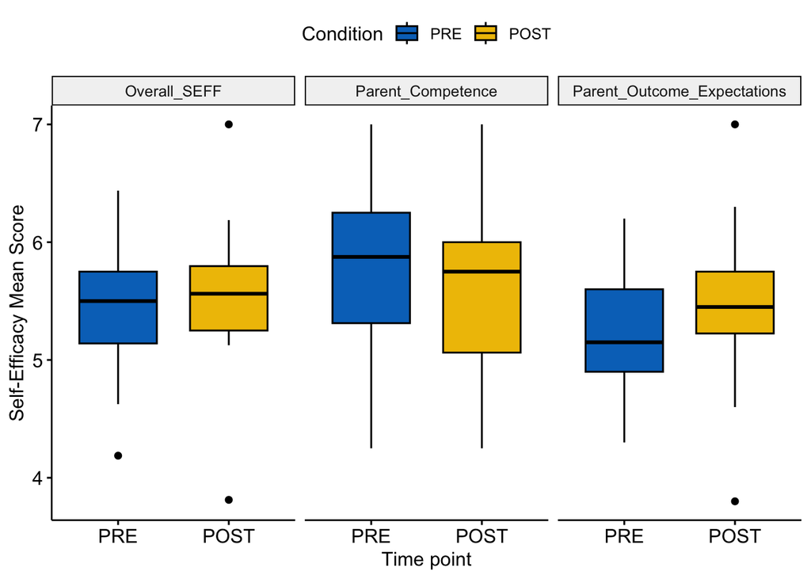

```r
library(ggpubr)

# Pairwise paired t-tests, positioned for the brackets
pwc_seff <- df_long %>%
  mutate(StudyID = factor(StudyID)) %>%
  filter(Calculation == "Mean") %>%
  group_by(Composite_Type) %>%
  pairwise_t_test(Score ~ Condition, paired = TRUE, detailed = TRUE, conf.level = 0.1, alternative = "greater") %>%
  add_xy_position(x= "Condition")

# AOV results
res.aov <-
  df_long %>%
  mutate(StudyID = factor(StudyID)) %>%
  filter(Calculation == "Mean") %>% # =="Overall_SEFF") %>%
  group_by(Composite_Type) %>%
  anova_test(Score ~ Condition + Error(StudyID/Condition))

# ggpubr plot
df_long %>%
  mutate(StudyID = factor(StudyID)) %>%
  filter(Calculation == "Mean") %>%
  ggboxplot(x = "Condition", y = "Score", fill = "Condition", palette = "jco",
          xlab = "Time point", ylab = "Self-Efficacy Mean Score")+
  facet_wrap(~Composite_Type)
```

```r
  #stat_pvalue_manual(pwc_seff, hide.ns = TRUE, tip.length = 0.01)+
  #labs(subtitle = get_test_label(res.aov, detailed = TRUE))
```

## 4.2 ANOVA

- To evaluate the effect of the intervention while strictly controlling for the participants’ baseline starting point, an ANOVA is run for each composite.
- CTA:: I was testing this, but ultimately I do not believe it is necessary, without three timepoints, running the ANOVA reduces to a t-test. The *slight* difference in the F and T statistics come from adjustments based on Sphericity (is variance equal across groups) or other factors.
  - This is also where the **poster** error came, the code was structured correctly, but I did not specify the sum/mean selection (used both) therefore there was a ‘doubling’ of data, and the effectsize also exploded.
- Will follow-up with potential improvements, if possible.

### Error Version

```r
# Run ANOVA, get Table.
results.ANCOVA <- sEFF.clean %>%
  rstatix::anova_test(POST_Overall_SEFF.Mean ~ PRE_Overall_SEFF.Mean)

get_anova_table(results.ANCOVA, correction = "auto") %>%
  kable(caption = "Error: Used the test statistic, which is functionally `does Pre-test predict Post-test'") %>%
  kable_styling(bootstrap_options = c("striped", "hover"), full_width = F)
```

Error: Used the test statistic, which is functionally `does Pre-test predict Post-test’

Effect

DFn

DFd

F

p

p<.05

ges

PRE_Overall_SEFF.Mean

1

20

33.1

0

0.623

### “Correct” Version (Approximates T-Test) Grouped ANOVA Tests

```r
results.aov <- df_long %>%
  filter(Calculation == "Mean") %>%
  group_by(Composite_Type) %>%
  rstatix::anova_test(Score ~ Condition + Error(StudyID/Condition))


get_anova_table(results.aov, correction = "auto") %>%
  kable(caption = "ANCOVA Results (Controlling for Baseline Pre-Scores)") %>%
  kable_styling(bootstrap_options = c("striped", "hover"), full_width = F)
```

Composite_Type

Effect

DFn

DFd

F

p

p<.05

ges

Overall_SEFF

Condition

1

21

2.025

0.169

0.011

Parent_Competence

Condition

1

21

0.983

0.333

0.007

Parent_Outcome_Expectations

Condition

1

21

7.427

0.013

0.049

## 4.4 Results & Preliminary Effectiveness

### Poster Snippets:

#### High Acceptability & Culturally Matched Support (From Poster)

```
- Qualitative feedback indicates the Autism Doula program was highly accepted by families. Caregivers highlighted the soft, comforting, and highly resourceful nature of the support.
- "I loved how my autism doula felt more like a friend than a therapist... anytime I needed information on anything! I could ask her & she'd find an answer for me." — Parent Participant
```

#### Quantitative Findings: Parent Self-Efficacy (From Stats Above)

```r
t_test_final %>%
  kable(caption = "Paired T-Test Results (Mean: Pre vs. Post)", digits = 3) %>%
  kable_styling(bootstrap_options = c("striped", "hover"), full_width = T)
```

Paired T-Test Results (Mean: Pre vs. Post)

Composite_Type

statistic

df

p

p.adj

p.adj.signif

effsize

magnitude

Overall_SEFF

1.423

21

0.085

0.170

ns

0.303

small

Parent_Competence

-0.991

21

0.834

0.834

ns

-0.211

small

Parent_Outcome_Expectations

2.725

21

0.006

0.018

0.581

moderate

## 4.5 Interpretation & Impact:

- There were measured EPISES changes on both ends of the scale, up and down, some quite large; the most extreme scores (balanced) were excluded from the core analysis.
- It is possible that this sample was not large enough to resolve the variance in baseline scores, and that a larger sample size would have yielded more statistically significant results.
- While this is *often* a claim (we need more participants) in the cases of the EIPSES scale, this may be particularly acute when utilizing this scale within a distinctly difference ethnicity group than that of the original scale construction,

#### Quoted from the paper:

*“Group differences were found across ethnicity subgroups for the Parent Outcome Expectations subscale. Tests of mean differences using a Bonferonni procedure revealed a statistically significant mean difference between Hispanic and White caregivers such that White caregivers rated themselves as having higher mean levels of outcome expectations efficacy than Hispanic caregivers (p < .01, d = .57). This effect was medium in size according to Cohen’s (1988, 1992) effect size conventions.”* **Guimond et al. / Early Intervention Scale 311**

- The paper also reported differences according to additional factors, such as SES and Education Status.
- My interpretation of the paper, is that it did not have any other large enough sub samples, (most relevantly in this case, of Black / African-American participants) to assess whether there would be statistically significant differences.
- The overall approach of measuring Self-Efficacy and particularly outcomes & expectations for families caring for individuals with clinical diagnoses likely requires additional investigation to incorporate this cultural lens and ensure efficacy of this scale to the study sample.

## 5. Visualizations

### 5.1 Pre vs. Post Boxplots (All Composites)

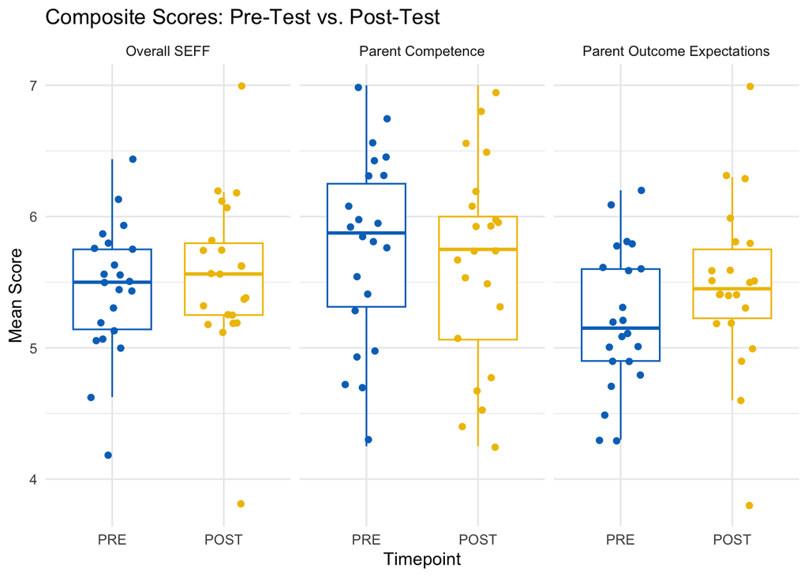

```r
df_long %>%
  filter(Calculation == "Mean",
         ) %>%
  mutate(Composite_Type = str_replace_all(Composite_Type, "_", " ")) %>%
  ggboxplot(
    x = "Condition", y = "Score",
    color = "Condition", palette = "jco",
    add = "jitter",
    facet.by = "Composite_Type",
    short.panel.labs = TRUE
  ) +
  labs(
    title = "Composite Scores: Pre-Test vs. Post-Test",
    x = "Timepoint",
    y = "Mean Score"
  ) +
  theme_minimal() +
  theme(legend.position = "none")
```

### 5.2 Baseline Regression Plots (ANOVA Visualized)

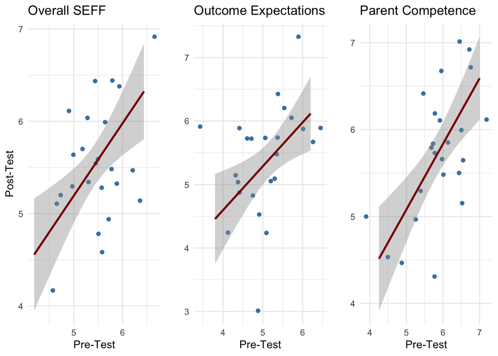

```r
p1 <- sEFF.mutated %>%
  ggplot(aes(x = PRE_Overall_SEFF.Mean, y = POST_Overall_SEFF.Mean)) +
  geom_jitter(color = "steelblue", width = 0.5, height = 0.5) +
  geom_smooth(method = "lm", color = "darkred") +
  labs(title = "Overall SEFF", x = "Pre-Test", y = "Post-Test") +
  theme_minimal()

p2 <- sEFF.mutated %>%
  ggplot(aes(x = PRE_Parent_Outcome_Expectations.Mean, y = POST_Parent_Outcome_Expectations.Mean)) +
  geom_jitter(color = "steelblue", width = 0.5, height = 0.5) +
  geom_smooth(method = "lm", color = "darkred") +
  labs(title = "Outcome Expectations", x = "Pre-Test", y = "") +
  theme_minimal()

p3 <- sEFF.mutated %>%
  ggplot(aes(x = PRE_Parent_Competence.Mean, y = POST_Parent_Competence.Mean)) +
  geom_jitter(color = "steelblue", width = 0.5, height = 0.5) +
  geom_smooth(method = "lm", color = "darkred") +
  labs(title = "Parent Competence", x = "Pre-Test", y = "") +
  theme_minimal()

ggarrange(p1, p2, p3, ncol = 3, nrow = 1)
```

### 5.3 Item-Level Distribution (Dot Plot)

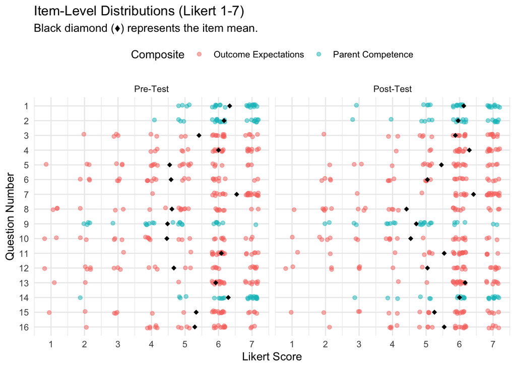

```r
sEFF.mutated %>%
  pivot_longer(cols = contains("_Q"), names_to = "Item", values_to = "Value") %>%
  mutate(
    Condition = if_else(str_detect(Item, "PRE_"), "Pre-Test", "Post-Test"),
    Condition = factor(Condition, levels = c("Pre-Test", "Post-Test")),
    Q_Num = as.numeric(str_extract(Item, "\\d+")),
    Q_Order = factor(Q_Num, levels = 1:16),
    Composite = if_else(Q_Num %in% c(1, 2, 9, 14), "Parent Competence", "Outcome Expectations")
  ) %>%
  filter(!is.na(Value)) %>%
  ggplot(aes(x = Value, y = fct_rev(Q_Order), color = Composite)) +
  geom_jitter(position = position_jitter(width = 0.2, height = 0.1), alpha = 0.5) +
  stat_summary(fun = "mean", geom = "point", color = "black", size = 2, shape = 18) +
  facet_wrap(~Condition) +
  scale_x_continuous(breaks = 1:7) +
  theme_minimal() +
  theme(legend.position = "top") +
  labs(
    title = "Item-Level Distributions (Likert 1-7)",
    subtitle = "Black diamond (♦) represents the item mean.",
    y = "Question Number",
    x = "Likert Score"
  )
```

### 5.4 Invidiual Score Changes (Mean)

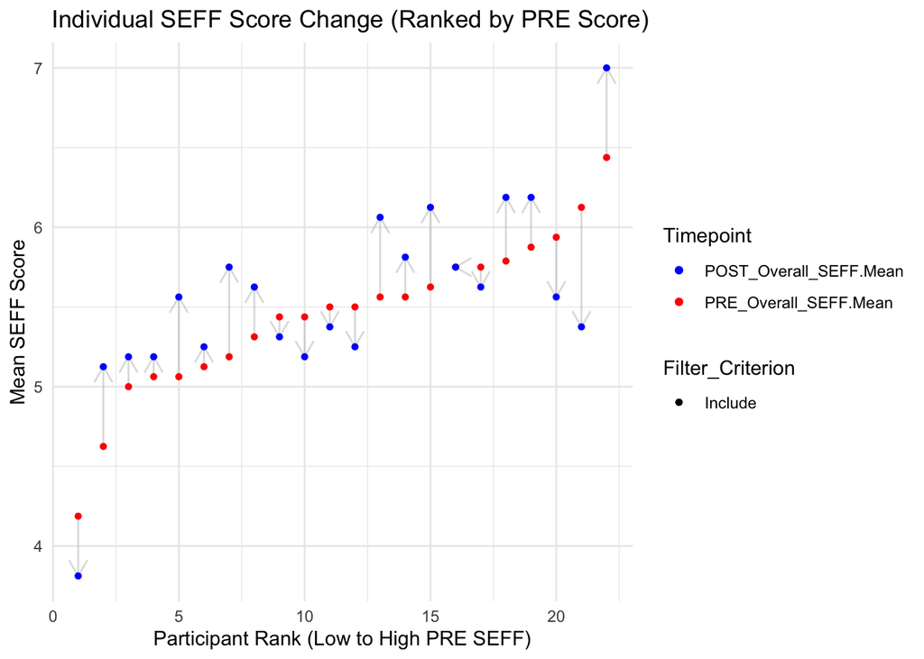

```r
sEFF.clean %>%
  arrange(PRE_Overall_SEFF.Mean) %>%
  mutate(
    Rank_Order = seq_along(PRE_Overall_SEFF.Mean),
    Pct_Order = percent_rank(PRE_Overall_SEFF.Mean)
  ) %>%
  ggplot(aes(x = Rank_Order, shape=Filter_Criterion)) +
  # 1. Add the arrows (vertical segments)
  geom_segment(aes(
    xend = Rank_Order,
    y = PRE_Overall_SEFF.Mean,
    yend = POST_Overall_SEFF.Mean
  ),
  arrow = arrow(length = unit(.35, "cm")), # Adds the arrow head
  color = "gray",
  alpha = 0.5) +

  # 2. Add the PRE points
  geom_point(aes(y = PRE_Overall_SEFF.Mean, color = "PRE_Overall_SEFF.Mean")) +

  # 3. Add the POST points
  geom_point(aes(y = POST_Overall_SEFF.Mean, color = "POST_Overall_SEFF.Mean")) +

  # Formatting
  scale_color_manual(values = c("PRE_Overall_SEFF.Mean" = "red", "POST_Overall_SEFF.Mean" = "blue")) +
  labs(
    title = "Individual SEFF Score Change (Ranked by PRE Score)",
    x = "Participant Rank (Low to High PRE SEFF)",
    y = "Mean SEFF Score",
    color = "Timepoint"
  ) +
  theme_minimal()
```

# Appendix

**CTA STATS NOTES:** - Mean replacement used for one participant response (entered as “strongly” - replaced with mean) - CEILING EFFECT –> Lots of mid to high scores; probably need more ‘upper range’ on the data (happens very often in surveys) participants tend to answer on the extremes, but not THE highest/lowest value.

```r
#check all unique strings in questions
uniques <- sEFF.named %>% select(contains("_Q")) %>%
  summarise(across(everything(), ~list(unique(.)))) %>%
  pivot_longer(everything(), names_to = "Question", values_to = "Unique_Responses") %>%
  unnest(cols = c(Unique_Responses))

table(uniques$Unique_Responses) %>% kable(caption="All survey text items, extraced for consistency check") %>%
  kable_styling(full_width = F)
```

All survey text items, extraced for consistency check

| Var1 | Freq |
| --- | --- |
| agree | 31 |
| disagree | 22 |
| neutral | 26 |
| somewhat agree | 25 |
| somewhat disagree | 24 |
| strongly | 1 |
| strongly agree | 24 |
| strongly disagree | 19 |